# P2 TPG

Dhea Dewanti & Nur Khamidah

2023-08-22

# Input Data

```r
x<-c(8.8, 8.5, 7.7, 4.9, 9.6, 10, 11.5, 11.6, 11.2, 10.7, 10, 6.8, 2589, 1186, 291,1276, 6633, 12125,
     36717, 43319, 10530, 3931, 1536, 61400)
data<-matrix(x, nrow=12, ncol=2)
data
```

```
##       [,1]  [,2]
##  [1,]  8.8  2589
##  [2,]  8.5  1186
##  [3,]  7.7   291
##  [4,]  4.9  1276
##  [5,]  9.6  6633
##  [6,] 10.0 12125
##  [7,] 11.5 36717
##  [8,] 11.6 43319
##  [9,] 11.2 10530
## [10,] 10.7  3931
## [11,] 10.0  1536
## [12,]  6.8 61400
```

# Mengaktifkan Library

```r
#install.packages("MVN")
library(MVN)
```

# Menggunakan Uji normalitas ganda menggunakan Mardia’s Skewness

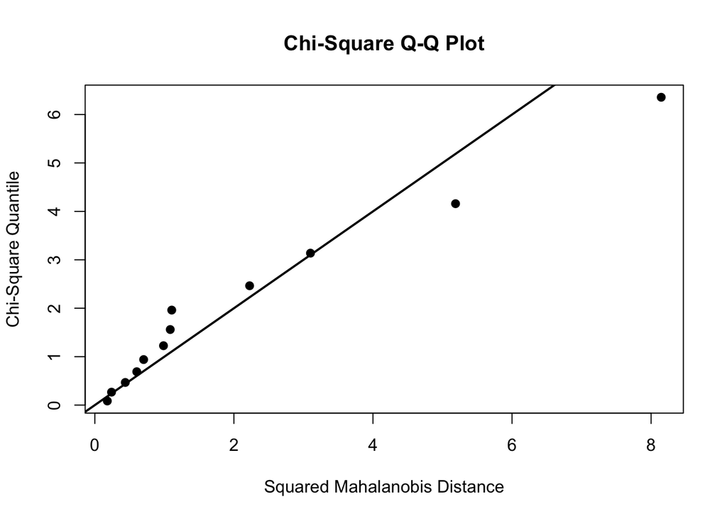

```r
mardia <- mvn(data, mvnTest = c("mardia"), covariance = TRUE, multivariatePlot = "qq")
```

```r
mardia
```

```
## $multivariateNormality
##              Test         Statistic            p value Result
## 1 Mardia Skewness  11.1215382968049 0.0252315192005968     NO
## 2 Mardia Kurtosis 0.590006258740303  0.555186453489953    YES
## 3             MVN              <NA>               <NA>     NO
##
## $univariateNormality
##               Test  Variable Statistic   p value Normality
## 1 Anderson-Darling  Column1     0.3122    0.5053    YES
## 2 Anderson-Darling  Column2     1.3825    0.0008    NO
##
## $Descriptives
##    n      Mean   Std.Dev Median   Min     Max   25th      75th       Skew
## 1 12     9.275     2.041    9.8   4.9    11.6    8.3    10.825 -0.6760453
## 2 12 15127.750 20400.481 5282.0 291.0 61400.0 1471.0 18273.000  1.1413585
##     Kurtosis
## 1 -0.6824234
## 2 -0.2880875
```

Dari hasil R diatas akan dilakukan pengujian hipotesis terhadap mardia skewness test sebagai berikut :  
Ho : Peubah ganda mengikuti distribusi normal  
H1 : Peubah ganda tidak mengikuti distribusi normal  
Sehingga dikesimpulan p-value = 0.02523 < α = 0.05 yaitu menolak Ho. Artinya bahwa peubah ganda tidak mengikuti distribusi normal. Dari Q-Q plot yang dihasilkan dari output R dibawah ini juga menunjukan bahwa sebaran dari data tidak mengikuti distribusi normal.

# Uji normalitas ganda menggunakan Henze-Zikler Test

```r
henze<-mvn(data, mvnTest = c("hz"), covariance = TRUE, multivariatePlot = "none")
henze
```

```
## $multivariateNormality
##            Test        HZ     p value MVN
## 1 Henze-Zirkler 0.9995781 0.004125476  NO
##
## $univariateNormality
##               Test  Variable Statistic   p value Normality
## 1 Anderson-Darling  Column1     0.3122    0.5053    YES
## 2 Anderson-Darling  Column2     1.3825    0.0008    NO
##
## $Descriptives
##    n      Mean   Std.Dev Median   Min     Max   25th      75th       Skew
## 1 12     9.275     2.041    9.8   4.9    11.6    8.3    10.825 -0.6760453
## 2 12 15127.750 20400.481 5282.0 291.0 61400.0 1471.0 18273.000  1.1413585
##     Kurtosis
## 1 -0.6824234
## 2 -0.2880875
```

Dari Henze-Zirkler’s Multivariate Normality Test menghasilkan nilai p-value = 0.004125 < α = 0.05. Hal ini berarti data mendukung untuk menolak Ho, dengan demikian dapat dikatakan bahwa peubah-peubah tersebut tidak mengikuti distribusi normal ganda.

# Uji Normalitas ganda menggunakan Royston

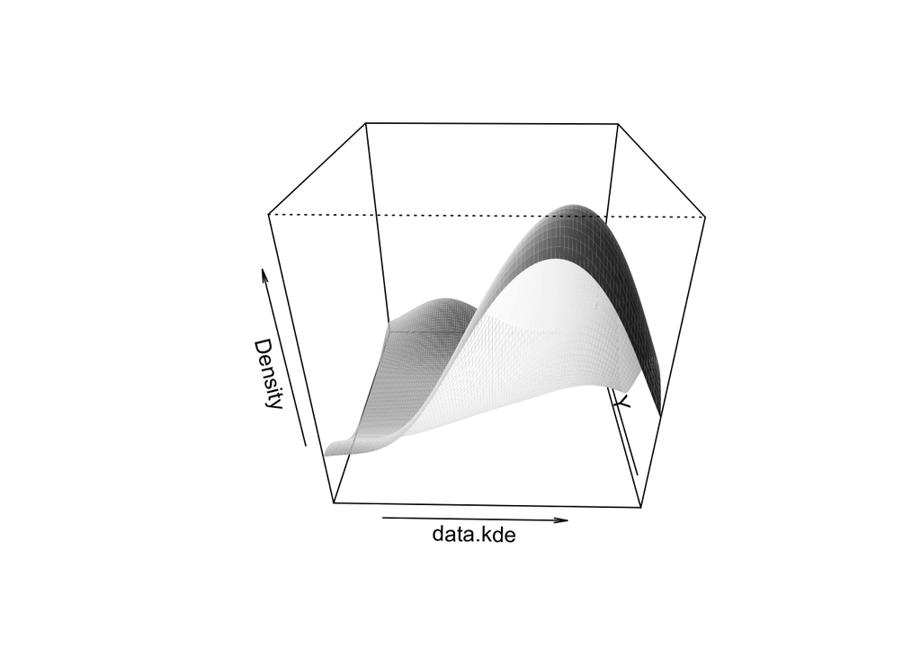

```r
royston<-mvn(data, mvnTest = c("royston"), covariance = TRUE, multivariatePlot = "persp")
```

```r
royston
```

```
## $multivariateNormality
##      Test        H     p value MVN
## 1 Royston 10.10069 0.006407917  NO
##
## $univariateNormality
##               Test  Variable Statistic   p value Normality
## 1 Anderson-Darling  Column1     0.3122    0.5053    YES
## 2 Anderson-Darling  Column2     1.3825    0.0008    NO
##
## $Descriptives
##    n      Mean   Std.Dev Median   Min     Max   25th      75th       Skew
## 1 12     9.275     2.041    9.8   4.9    11.6    8.3    10.825 -0.6760453
## 2 12 15127.750 20400.481 5282.0 291.0 61400.0 1471.0 18273.000  1.1413585
##     Kurtosis
## 1 -0.6824234
## 2 -0.2880875
```

Dari Royston Test menghasilkan nilai p-value = 0.0064 < α = 0.05. Hasil uji ini juga menunjukkan data mendukung untuk menolak Ho, dengan demikian dapat dikatakan bahwa peubah-peubah tersebut tidak mengikuti distribusi normal ganda.

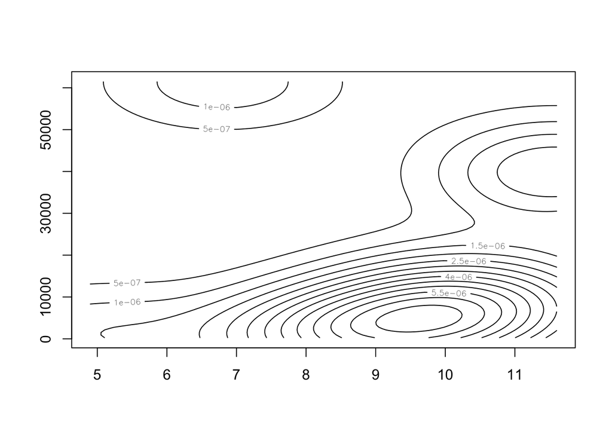

```r
royston<-mvn(data, mvnTest = c("royston"), covariance = TRUE, multivariatePlot = "contour")
```

```r
royston
```

```
## $multivariateNormality
##      Test        H     p value MVN
## 1 Royston 10.10069 0.006407917  NO
##
## $univariateNormality
##               Test  Variable Statistic   p value Normality
## 1 Anderson-Darling  Column1     0.3122    0.5053    YES
## 2 Anderson-Darling  Column2     1.3825    0.0008    NO
##
## $Descriptives
##    n      Mean   Std.Dev Median   Min     Max   25th      75th       Skew
## 1 12     9.275     2.041    9.8   4.9    11.6    8.3    10.825 -0.6760453
## 2 12 15127.750 20400.481 5282.0 291.0 61400.0 1471.0 18273.000  1.1413585
##     Kurtosis
## 1 -0.6824234
## 2 -0.2880875
```

Berdasarkan beberapa uji normalitas ganda di atas, dapat disimpulkan bahwa data tidak menyebar multivariat normal. Sehingga dapat dilakukan penangan lanjutan terhadap data tersebut, dapat menggunakan transformasi normal atau metode lainnya.